# DSCI353-353m-453: Class 05a-p Bootstrap for Mixed Effects Models

Profs: R. H. French, L. S. Bruckman, P. Leu, K. Davis, S. Cirlos

TAs: W. Oltjen, K. Hernandez, M. Li, M. Li, D. Colvin

13 February, 2023

#### Class Readings, Assignments, Syllabus Topics

##### Textbooks

- Text Books for DSCI353/353M/453
  - [R4DS: Wickham: R for Data Science](https://r4ds.had.co.nz/)
  - [ISLR: Intro to Statistical Learning with R, 2nd Ed.](https://www.statlearning.com/)
  - DLwR: Deep Learning with R, Chollet, Allaire,
  - [DLGB: Deep Learning, Goodfellow, Bengio, Courville](https://www.deeplearningbook.org/)
- Magazine Articles about Deep Learning
  - DL1 to DL12 are “Deep Learning” articles in 3-readings/2-articles/
- Books from DSCI351/351M/451
  - [Peng: R Programming for Data Science](https://leanpub.com/rprogramming)
  - [Peng: Exploratory Data Analysis with R](https://leanpub.com/exdata)
  - [Open Intro Stats, v4](https://openintro.org/os)
  - [R4DS: Wickham: R for Data Science](https://r4ds.had.co.nz/)

##### Tidyverse Cheatsheets, Functions and Reading Your Code

- Look at the Tidyverse Cheatsheet
  - **Tidyverse For Beginners Cheatsheet**
    - In the Git/20s-dsci353-353m-453-prof/3-readings/3-CheatSheets/ folder
  - **Data Wrangling with dplyr and tidyr Cheatsheet**

  Tidyverse Functions & Conventions
  - The pipe operator `%>%`
  - Use `dplyr::filter()` to subset data row-wise.
  - Use `dplyr::arrange()` to sort the observations in a data frame
  - Use `dplyr::mutate()` to update or create new columns of a data frame
  - Use `dplyr::summarize()` to turn many observations into a single data point
  - Use `dplyr::arrange()` to change the ordering of the rows of a data frame
  - Use `dplyr::select()` to choose variables from a tibble,
    - keeps only variables you mention
  - Use `dplyr::rename()` keeps all the variables and renames variables
    - rename(iris, petal_length = Petal.Length)
  - These can be combined using `dplyr::group_by()`
    - which lets you perform operations “by group”.
  - The `%in%` matches conditions provided by a vector using the c() function
  - The **forcats** package has tidyverse functions
    - for factors (categorical variables)
  - The **readr** package has tidyverse functions
    - to read_…, melt_… col_…, parse_… data and objects

Reading Your Code: Whenever you see

- The assignment operator `<-`, think **“gets”**
- The pipe operator, `%>%`, think **“then”**

##### Syllabus

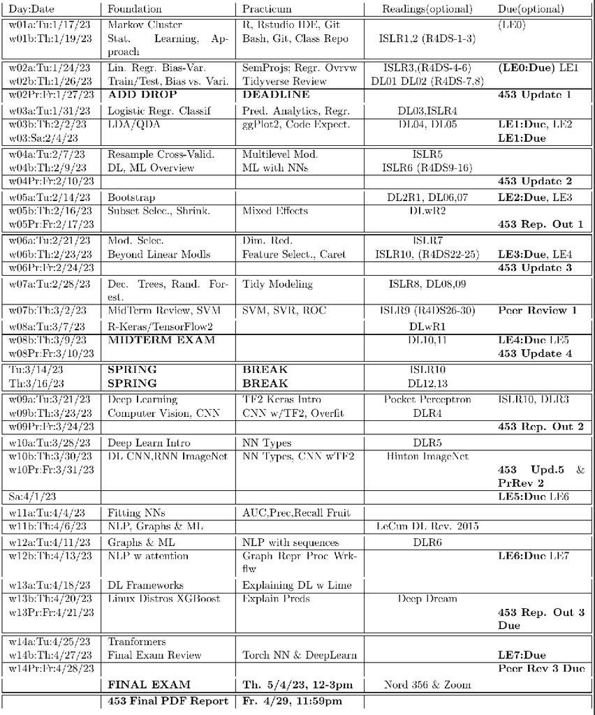

#### Bootstrap applied to Mixed Effects Models

- Bootstrap is one of the most famous resampling techniques
  - and is very useful way to get confidence intervals
  - in situations where classical approach (t- or z- tests) would fail.

##### What is Bootstrap?

- Lets show a simple bootstrap example
  - using the height of 100 person in the population.

```r
set.seed(20151101)
height <- rnorm(100, 175, 6)
```

Now we will resample

- with replacement 1000 times
- and compute the median:

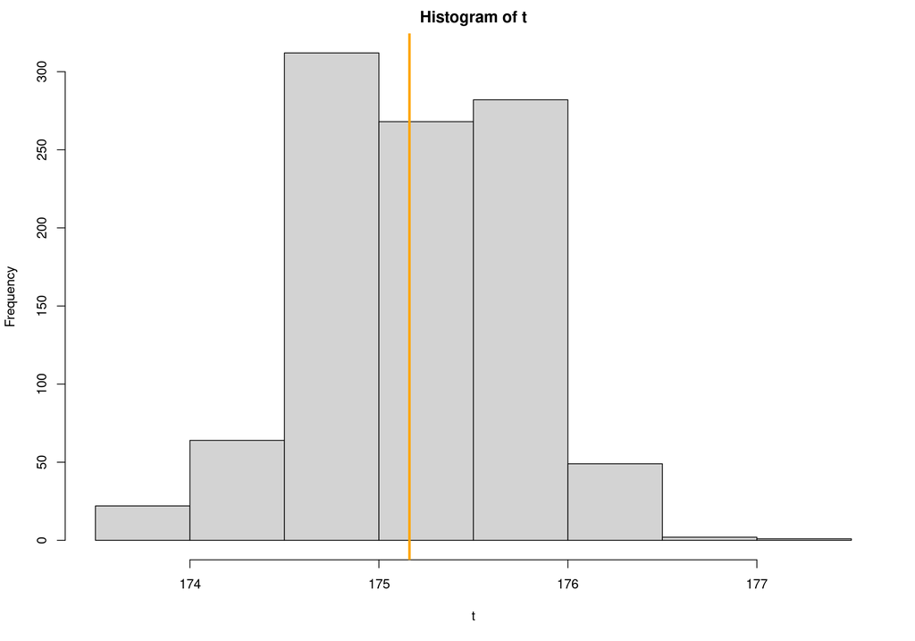

```r
t0 <- median(height)
t <-
  sapply(1:1000, function(x)
    median(sample(
      x = height, size = 100,
      replace = TRUE
    )))
hist(t)
abline(v = t0, col = "orange", lwd = 3)
```

And this is the histogram that we get.

And that’s it, this is the essence of bootstrap:

- resampling the observed data with replacement
  - and computing the statistic of interest
  - (here the median)
  - many times on the resampled data
- to get a distribution of the statistic of interest.
- This distribution of the statistic of interest can then be used to compute,
  - for example, confidence intervals.

##### When to use Bootstrap?

- Bootstrap is used to enable inference on the statistic of interest
  - when the true distribution of this statistic is unknown.
- For example in a linear model the parameters of interest
  - have a known distribution
  - from which standard errors and formal tests can be performed.
- On the other hand for some statistics
  - (median, differences between two models …),
  - if the analyst do not want to spend time writing down equations,
- [bootstrapping](https://en.wikipedia.org/wiki/Bootstrapping_%28statistics%29) might be a great approach
  - to get standard errors and confidence intervals
  - from the bootstrapped distribution.

##### When will Bootstrap Fail?

- There are some situations where bootstrapped will fail:
  - 1. the statistic of interest is at the edge of the parameter space
    - (like minimum or maximum),
    - the bootstrapped distribution does not converge
      - (as the number of bootstrap sample increase to infinity)
      - to the true distribution of the statistic.
  2. sample size is small,
  - bootstrapping will not increase the power of statistical tests.
  - If you sample too few data to detect an effect of interest,
  - using bootstrap will not magically solve your problem
  - even worse the bootstrap approach will perform less well than others.

##### How many bootstrap samples

- [As much as possible](https://stats.stackexchange.com/questions/86040/rule-of-thumb-for-number-of-bootstrap-samples) will be the answer.
- Note that in here we used low numbers to speed up the computations for class

#### Non-parametric and parametric bootstrap using the `boot` package

- The boot library in R is very convenient
  - to easily compute confidence intervals from bootstrap samples.

**Non-parametric bootstrap with boot:**

```r
library(boot)
b1 <- boot(
  data = height,
  statistic = function(x, i)
    median(x[i]),
  R = 1000
)
boot.ci(b1)
```

```
BOOTSTRAP CONFIDENCE INTERVAL CALCULATIONS
Based on 1000 bootstrap replicates

CALL :
boot.ci(boot.out = b1)

Intervals :
Level      Normal              Basic
95%   (174.0, 176.3 )   (174.1, 176.4 )

Level     Percentile            BCa
95%   (173.9, 176.2 )   (173.9, 176.2 )
Calculations and Intervals on Original Scale
```

**Parametric bootstrap with boot:**

```r
x <- runif(100, -2, 2)
y <- rnorm(100, 1 + 2 * x, 1)
dat <- data.frame(x = x, y = y)
```

##### Lets do a simple example with a linear model

```r
m <- lm(y ~ x)
```

We are interested in getting

- the confidence intervals
  - for the coefficient of the model:

```r
foo <- function(out) {
  m <- lm(y ~ x, out)
  coef(m)
}
```

The function rgen

- generate new response vector from the model:

```r
rgen <- function(dat, mle) {
  out <- dat
  out$y <- unlist(simulate(mle))
  return(out)
}
```

Now generate a 1000 bootstrap sample

```r
b2 <- boot(
  dat,
  foo,
  R = 1000,
  sim = "parametric",
  ran.gen = rgen,
  mle = m
)
```

Compute the confidence intervals

- for the two coefficients:
  - index = 1 and index = 2

```r
boot.ci(b2, type = "perc", index = 1)
```

```
BOOTSTRAP CONFIDENCE INTERVAL CALCULATIONS
Based on 1000 bootstrap replicates

CALL :
boot.ci(boot.out = b2, type = "perc", index = 1)

Intervals :
Level     Percentile
95%   ( 1.039,  1.423 )
Calculations and Intervals on Original Scale
```

```r
boot.ci(b2, type = "perc", index = 2)
```

```
BOOTSTRAP CONFIDENCE INTERVAL CALCULATIONS
Based on 1000 bootstrap replicates

CALL :
boot.ci(boot.out = b2, type = "perc", index = 2)

Intervals :
Level     Percentile
95%   ( 1.832,  2.164 )
Calculations and Intervals on Original Scale
```

In the non-parametric case

- `boot` expects two arguments in the function returning the statistic of interest:
  - the first one is the object from which to compute the statistic
  - and the second is a vector of
    - index (`i`),
    - frequencies (`f`)
    - or weight (`w`)
    - defining the bootstrap sample.
- In our example, `boot` will generate a series of indices (named `i`)
  - with replacement
  - and these will be used to subset the original height vector.

In the parametric case the function returning the statistic(s) of interest

- only needs one argument: the original dataset.
- We then need to supply another function (`ran.gen`)
  - describing how to generate the new data,
  - it needs to return an object of the same form as the original dataset.
- This random data generating function need two arguments:
  - the first one is the original dataset
  - and the second one contain maximum likelihood estimate
    - for the parameter of interest,
    - basically a model object.
  - The new dataset generated by the ran.gen function
    - will then be passed to the statistics function
    - to compute the bootstrapped value for the statistic of interest.
  - It is then straightforward to get
    - the confidence intervals for the statistic
    - using `boot.ci`.

#### Bootstrap applied to mixed-effect models

- Mixed-effect models are rather complex
  - and the distributions or numbers of degrees of freedom
  - of various outputs from them (like parameters …)
  - is not known analytically.
- Which is why the author of the `lme4` package recommends
  - the use of bootstrap to get
    - confidence intervals around the model parameters,
      - the predicted values
    - but also to get p-values from likelihood ratio tests.

In 3-readings/4-MatSci-And-SemProjReadings

- There is a good example of fixed- and mixed-effects modeling
  - In Gok et al. - 2017 - Predictive models of poly(ethylene-terephthalate) .pdf

##### A simple random intercept model:

```r
library(lme4)
dat <- data.frame(x = runif(100, -2, 2), ind = gl(n = 10, k = 10))
dat$y <-
  1 + 2 * dat$x + rnorm(10, 0, 1.2)[dat$ind] + rnorm(100, 0, 0.5)
m <- lme4::lmer(y ~ x + (1 | ind), dat)
```

Get the bootstrapped confidence intervals

- for the model parameters:

```r
b_par <- bootMer(x = m, FUN = fixef, nsim = 200)
boot.ci(b_par, type = "perc", index = 1)
```

```
BOOTSTRAP CONFIDENCE INTERVAL CALCULATIONS
Based on 200 bootstrap replicates

CALL :
boot.ci(boot.out = b_par, type = "perc", index = 1)

Intervals :
Level     Percentile
95%   (-0.3984,  1.1845 )
Calculations and Intervals on Original Scale
Some percentile intervals may be unstable
```

```r
boot.ci(b_par, type = "perc", index = 2)
```

```
BOOTSTRAP CONFIDENCE INTERVAL CALCULATIONS
Based on 200 bootstrap replicates

CALL :
boot.ci(boot.out = b_par, type = "perc", index = 2)

Intervals :
Level     Percentile
95%   ( 1.834,  2.014 )
Calculations and Intervals on Original Scale
Some percentile intervals may be unstable
```

Or alternatively:

```r
confint(
  m,
  parm = c(3, 4),
  method = "boot",
  nsim = 200,
  boot.type = "perc"
)
```

```
Computing bootstrap confidence intervals ...
```

```
                2.5 %   97.5 %
(Intercept) -0.211244 1.359807
x            1.841195 2.041312
```

Get the bootstrapped confidence intervals

- around the regression curves:

```r
new_dat <- data.frame(x = seq(-2, 2, length = 20))
mm <- model.matrix(~ x, data = new_dat)
predFun <- function(.)
  mm %*% fixef(.)
bb <- bootMer(m, FUN = predFun, nsim = 200) #do this 200 times
```

As we did this 200 times

- the 95% CI will be bordered
- by the 5th and 195th value:

```r
bb_se <- apply(bb$t, 2, function(x)
  x[order(x)][c(5, 195)])
new_dat$LC <- bb_se[1,]
new_dat$UC <- bb_se[2,]
new_dat$pred <- predict(m, newdata = new_dat, re.form =  ~ 0)
```

Plot the results

```r
plot(y ~ x, dat, pch = 16)
lines(pred ~ x, new_dat, lwd = 2, col = "orange")
```

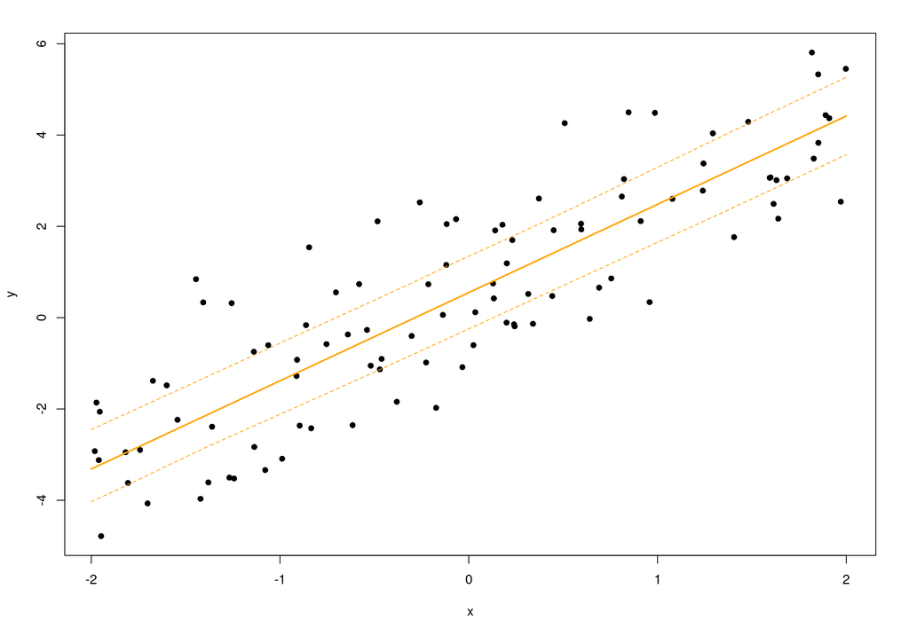

```r
lines(LC ~ x, new_dat, lty = 2, col = "orange")
lines(UC ~ x, new_dat, lty = 2, col = "orange")
```

Drawing confidence intervals around the regression curves

- is tricky due to the random effect estimated values
  - which comes with there own uncertainty
  - (have a look at `dotplot(ranef(m,condVar=TRUE))` to see it).

Bootstrapping is an efficient way to take these uncertainties into account

- since the random deviates are re-computed for each draw.

Finally getting p-values for the effect of a fixed-effect term

- can be done using a parametric bootstrap approach as described here
- and implemented in the function `PBmodcomp`
  - from the `pbkrtest` package.
- In the output of `PBmodcomp`
  - the bootstrapped p-values is in the PBtest line,
  - the LRT line reports the standard p-value
    - assuming a chi-square distribution
    - for the LRT value.

```r
library(pbkrtest)
? PBmodcomp
```

#### Links

- Lionel Hertzog, “Introduction to bootstrap with applications to mixed-effect models”, Nov. 25, 2015.
- T. Hastie, R. Tibshirani, and J. Friedman, The Elements of Statistical Learning: Data Mining, Inference, and Prediction, Second Edition, 2nd ed. New York: Springer-Verlag, 2009 [Online]. Available: https://web.stanford.edu/~hastie/ElemStatLearn/.
- Bradley Efron and Robert J Tibshirani, An introduction to the bootstrap, vol. 57. Chapman & Hall/CRC Monographs on Statistics and Applied Probability, 1993 [Online]. Available: https://www.routledge.com/An-Introduction-to-the-Bootstrap/Efron-Tibshirani/p/book/9780412042317
- D. Bates, M. Mächler, B. Bolker, and S. Walker, “Fitting Linear Mixed-Effects Models using lme4,” Journal of Statistical Software, vol. 67, no. 1, pp. 1–48, 2015, doi: 10.18637/jss.v067.i01.